```python
import requests
import csv
import re
import pandas as pd
from bs4 import BeautifulSoup as bs
import matplotlib.pyplot as plt
import seaborn as sns
%matplotlib inline
plt.style.use('ggplot')
```

# Pulling For Sale and Rental Data with Web Scraping

Trulia.com's rental search results presented in a list conducive to web scraping. Baltimore was searched, and then large apartment complexes excluded. Due to the vague pricing (typically a range without specific unit attributes), data from those units could not be collected in a useful way. Some manual monitoring was required if the program stalled. The script prints out the search pages as it scapes so it we be re-run starting at the next page.

Results are saved in a csv file to be used in other analysis and across into the R interface.

```python
def rental_scrape():
    base='https://www.trulia.com/for_rent/Baltimore,MD/SINGLE-FAMILY_HOME,APARTMENT%7CCONDO%7CTOWNHOUSE%7CMULTI-FAMILY%7CLOFT_type'
    for i in range(0,1000):
        data=requests.get(base+'/'+str(i)+'_p')
        soup=bs(data.content, "lxml")
        results_data=soup.find_all('li',{'class':'hover propertyCard property-data-elem clickable'})
        if results_data==[]:
            break
        with open('rentals4.csv', 'a') as csv_file:
            writer = csv.writer(csv_file)
            for item in results_data:
                try:
                    street_address_base=item.find_all("span",{'itemprop': 'streetAddress'})[0].text
                    street_address=street_address_base.replace(',',' ')
                except:
                    street_address='N/A'
                try:
                    city=item.find_all("span",{'itemprop': 'addressLocality'})[0].text
                except:
                    city='N/A'
                try:
                    zipcode=item.find_all("span",{'itemprop': 'postalCode'})[0].text
                except:
                    zipcode='N/A'
                try:
                    price_base=item.find_all("span",{'class': 'typeEmphasize'})[0].text
                    price=price_base.replace(',','').replace('$','')
                except:
                    price='N/A'
                try:
                    bed_bath=item.find_all("div",{'class': 'col cols3'})[0].text
                    bedrooms=bed_bath.split("\n")[1].split(" ")[0]
                    baths=bed_bath.split("\n")[2].split(" ")[0]
                except:
                    bedrooms='N/A'
                    baths='N/A'
                try:
                    latitude=item.find_all("meta",{'itemprop': 'latitude'})[0]['content']
                except:
                    latitude='N/A'
                try:
                    longitude=item.find_all("meta",{'itemprop': 'longitude'})[0]['content']
                except:
                    longitude='N/A'
                sqft_base=item.find_all("div",{'class': 'col cols4 '})[0].text
                sqft_regex=re.compile(r'(\d+)\s(sqft)')
                type_regex=re.compile(r'townhouse|rental|house')
                try:
                    sqft=sqft_regex.search(sqft_base).group(1)
                except:
                    sqft="N/A"
                try:
                    unittype=type_regex.search(sqft_base).group()
                except:
                    unittype="N/A"
                writer.writerow([street_address,city,zipcode,price,bedrooms,baths,latitude,longitude,sqft,unittype])
        print('pg ',i)
```

We faced difficulty in finding a site to pull house sale information, as many sites default to a map view after searching that displays little information on the specific property on the results page. URLs for individual listings were unique and could not be interated through. Homes.com was found to work, but some information, such as SQFT was often missing. Regex had to be used to pull information from blocks of text within the same HTML tag.

Although not listed on the page, in the HTML was the latitude and longitude, which was scraped for potential mapping applications.

```python
def sale_scrape():
    base='http://www.homes.com/for-sale/baltimore-md/'
    for i in range(1,1000):
        if i ==1:
            data=requests.get(base)
        else:
            data=requests.get(base+'p'+str(i))
        soup=bs(data.content, "lxml")
        results_data=soup.find_all('div',{'class': 'result-list _listing-result'})
        if results_data==[]:
            break
        with open('forsale.csv', 'a') as csv_file:
            writer = csv.writer(csv_file)
            for item in results_data:
                try:
                    address=item.find_all("span",{'itemprop': 'streetAddress'})[0].text
                except:
                    address="N/A"
                try:
                    locality=item.find_all("span",{'itemprop': 'addressLocality'})[0].text
                except:
                    locality="N/A"
                try:
                    state=item.find_all("span",{'itemprop': 'addressRegion'})[0].text
                except:
                    state='N/A'
                try:
                    zipcode=item.find_all("span",{'itemprop': 'postalCode'})[0].text
                except:
                    zipcode='N/A'
                try:
                    latitude=item.find_all("meta",{'itemprop': 'latitude'})[0]['content'].strip()
                    longitude=item.find_all("meta",{'itemprop': 'longitude'})[0]['content'].strip()
                except:
                    latitude='N/A'
                    longitude='N/A'
                try:
                    price=item.find_all("div",{'class':'result-price'})[0].text.strip().replace('$','').replace(',','')
                except:
                    price='N/A'
                sqft_regex=re.compile(r'(Sqft:)\s(.*)')
                beds_regex=re.compile(r'(Beds:)\s(.*)')
                bathfull_regex=re.compile(r'(\d)\s(full)')
                bathhalf_regex=re.compile(r'(\d)\s(half)')
                lot_regex=re.compile(r'(Size:)\s(\S*)')
                year_regex=re.compile(r'(Built:)\s(\S*)')
                attribute_list=item.find_all("div", {'class':'m'})[0].text
                try:
                    sqft_raw=sqft_regex.search(attribute_list).group(2)
                    sqft=sqft_raw.replace(',','').replace("--","N/A")
                except:
                    sqft="N/A"
                try:
                    beds=beds_regex.search(attribute_list).group(2)
                except:
                    beds="N/A"
                try:
                    bathfull=int(bathfull_regex.search(attribute_list).group(1))
                    try:
                        bathhalf=int(bathhalf_regex.search(attribute_list).group(1))
                    except:
                        bathhalf=0
                    baths=bathfull+(.5*bathhalf)
                except:
                    baths="N/A"
                try:
                    lot_acres_raw=lot_regex.search(attribute_list).group(2)
                    lot_acres=lot_acres_raw.replace("--","N/A")
                except:
                    lot_acres="N/A"
                try:
                    year_built=year_regex.search(attribute_list).group(2)
                except:
                    year_built="N/A"
                writer.writerow([address,locality,state,zipcode,latitude,longitude,price,sqft,beds,baths,lot_acres,year_built])
        print('pg.',i)
```

# Pulling into Data Frames

We then read the csv into data frames for varible exploration. One issue was discovered that price was showing as string, since some prices had '+' at the end. This was transformed into numeric.

```python
rent_df=pd.read_csv("rentals3.csv",names=['street_address','city','zipcode','price','bedrooms','baths','latitude','longitude','sqft','unittype'])
sale_df=pd.read_csv("forsale.csv",names=['address','locality','state','zipcode','latitude','longitude','price','sqft','beds','baths','lot_acres','year_built'])
sale_df['price']=pd.to_numeric(sale_df['price'],errors='coerce')
sale_df['beds']=pd.to_numeric(sale_df['beds'],errors='coerce')
```

Wanting to focus only on Baltmore city, we filtered out properties outside of the city

```python
balt_city_zips=['21203','21215','21209','21210','21212','21239','21214','21234','21236','21207','21216','21217','21211','21218','21251','21206','21213','21228','21229','21223','21201','21202','21231','21287','21205','21237','21227','21230','21231','21224','21222','21225','21226']
city_zips=[]
for i in balt_city_zips:
    city_zips.append(int(i))
#filtering the results to only include zips found in Baltimore City
city_filter_sale=sale_df[sale_df['zipcode'].isin(city_zips)]
city_filter_rent=rent_df[rent_df['zipcode'].isin(city_zips)]
```

```python
city_filter_sale.head()
```

|  | address | locality | state | zipcode | latitude | longitude | price | sqft | beds | baths | lot_acres | year_built |
| --- | --- | --- | --- | --- | --- | --- | --- | --- | --- | --- | --- | --- |
| 0 | 1530 Greendale Road | Baltimore | MD | 21218 | 39.336970 | -76.592360 | 138900.0 | NaN | 3.0 | 2.0 | NaN | 1951 |
| 1 | 408 Parrish Street South | Baltimore | MD | 21223 | 39.282890 | -76.641520 | 49900.0 | NaN | 2.0 | 1.0 | NaN | 1915 |
| 2 | 9 Midvale Rd | Baltimore | MD | 21210 | 39.355020 | -76.639060 | 825000.0 | NaN | 5.0 | 4.0 | 0.46 | 1907 |
| 4 | 9202 Teakwood Rd | Baltimore | MD | 21234 | 39.408375 | -76.532288 | 184900.0 | NaN | 3.0 | 2.5 | 0.05 | 1983 |
| 5 | 4213 Powell Avenue | Baltimore | MD | 21206 | 39.346730 | -76.537240 | 139900.0 | 1668.0 | 3.0 | 2.0 | 0.15 | 1920 |

```python
city_filter_rent.head()
```

|  | street_address | city | zipcode | price | bedrooms | baths | latitude | longitude | sqft | unittype |
| --- | --- | --- | --- | --- | --- | --- | --- | --- | --- | --- |
| 0 | 2225 E Lombard St | Baltimore | 21231 | 4000 | 3.0 | 3.5 | 39.290585 | -76.585370 | 4178.0 | rental |
| 1 | 1044 S Charles St #D | Baltimore | 21230 | 1300 | 1.0 | 1.0 | 39.276930 | -76.614630 | NaN | rental |
| 2 | 3604 Fait Ave | Baltimore | 21224 | 2000 | 2.0 | 1.0 | 39.283806 | -76.566340 | NaN | townhouse |
| 3 | 2404 Ridgely St | Baltimore | 21230 | 1400 | 3.0 | 2.5 | 39.263584 | -76.643616 | NaN | townhouse |
| 4 | 912 S Decker Ave | Baltimore | 21224 | 2400 | 3.0 | 3.0 | 39.281800 | -76.573555 | NaN | townhouse |

```python
city_filter_rent.count()
```

```
street_address    2004
city              1992
zipcode           2004
price             2004
bedrooms          1947
baths             1987
latitude          2004
longitude         2004
sqft               980
unittype          1984
dtype: int64
```

```python
city_filter_sale.count()
```

```
address       1628
locality      1628
state         1628
zipcode       1628
latitude      1615
longitude     1615
price         1626
sqft           595
beds          1601
baths         1600
lot_acres     1112
year_built    1628
dtype: int64
```

# Mapping for Data Exploration

```python
import folium
from folium.plugins import MarkerCluster
```

We started with a visualization of the distribution of properties across the city, potentially identifying a hot rental area.

```python
latitudes=[]
longitudes=[]
prices=[]
for index, row in city_filter_rent.iterrows():
    latitudes.append(row['latitude'])
    longitudes.append(row['longitude'])
    prices.append(row['price'])
```

### Geographic Rental Clusters

```python
coors=zip(latitudes,longitudes)
coords=list(coors)
map_object2 = folium.Map(location=[39.29, -76.61], zoom_start=12,tiles='Cartodb Positron')
map_object2.add_children(MarkerCluster(locations=coords, popups=coords))
map_object2
```

[interactive chart not shown]

## Visualizing Price Difference

To get an idea of pricing of properties, we wanted to map the properties on a color scale by price. Realizing that prices varied by bedrooms, we used 3 bedroom properies, the rental property number of bedrooms we have the most data for.

```python
city_filter_rent['bedrooms'].groupby(city_filter_rent['bedrooms']).count()
```

```
bedrooms
1.0    281
2.0    670
3.0    790
4.0    168
5.0     34
6.0      4
Name: bedrooms, dtype: int64
```

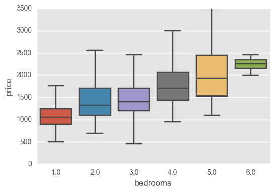

```python
sns.boxplot(data=city_filter_rent, x='bedrooms',y='price',showfliers=False)
```

```python
threebed=rent_df[rent_df['bedrooms']==3]
latitudes3=[]
longitudes3=[]
prices3=[]
for index, row in threebed.iterrows():
    latitudes3.append(row['latitude'])
    longitudes3.append(row['longitude'])
    prices3.append(row['price'])
```

We chose to color scale with 10 colors based on the percentile of price within the three bedroom rental subset

```python
import numpy as np
percents=[]
for i in range(10,110,10):
    p=np.percentile(threebed['price'],i)
    percents.append(int(p))
percents
```

```
[1000, 1100, 1250, 1300, 1399, 1500, 1600, 1800, 2300, 7000]
```

```python
scale=['#80b3ff','#66a3ff','#4d94ff','#3385ff','#1a75ff','#0066ff','#005ce6','#0052cc','#0047b3','#003d99']
colors=[]
for index, row in threebed.iterrows():
    if row['price'] <= percents[0]:
        colors.append(scale[0])
    elif row['price'] > percents[0] and row['price'] <= percents[1]:
        colors.append(scale[1])
    elif row['price'] > percents[1] and row['price'] <= percents[2]:
        colors.append(scale[2])
    elif row['price'] > percents[2] and row['price'] <= percents[3]:
        colors.append(scale[3])
    elif row['price'] > percents[3] and row['price'] <= percents[4]:
        colors.append(scale[4])
    elif row['price'] > percents[4] and row['price'] <= percents[5]:
        colors.append(scale[5])
    elif row['price'] > percents[5] and row['price'] <= percents[6]:
        colors.append(scale[6])
    elif row['price'] > percents[6] and row['price'] <= percents[7]:
        colors.append(scale[7])
    elif row['price'] > percents[7] and row['price'] <= percents[8]:
        colors.append(scale[8])
    else:
        colors.append(scale[9])
```

```python
map_data=zip(latitudes3,longitudes3,prices3,colors)
all_map_data=list(map_data)

map_object = folium.Map(location=[39.29, -76.61], zoom_start=11,tiles='Cartodb Positron')
for i in all_map_data:
    folium.CircleMarker([i[0],i[1]],
        radius=150,
        popup=str(i[2]),
        color=i[3],
        fill_color=i[3],
        ).add_to(map_object)
```

### Three Bedroom Units, Light to Dark: Lower to Higher Prices

```python
map_object
```

[interactive chart not shown]

Obeserved from the map where the geographical pricing differences, particularly the highest prices around the inner harbor and just east of I-83. To further explore geographic price differences, price distrbutions were plotted by zip code.

## Exploring Pricing Distributions by Zipcode

```python
#Short function to sort a given parameter before plotting
def boxplot2_sorted(df, by, column, title):
    df2 = pd.DataFrame({col:vals[column] for col, vals in df.groupby(by)})
    meds = df2.median().sort_values()
    g=sns.boxplot(data=df2[meds.index],showfliers=False)
    sns.plt.title(title)
    for item in g.get_xticklabels():
        item.set_rotation(90)
    return g
```

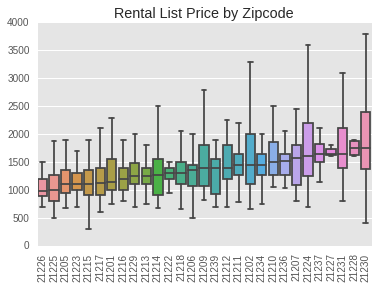

```python
boxplot2_sorted(city_filter_rent, by=["zipcode"], column="price",title="Rental List Price by Zipcode")
```

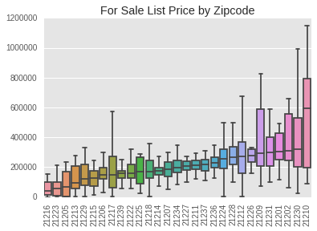

```python
boxplot2_sorted(city_filter_sale, by=["zipcode"], column="price",title="For Sale List Price by Zipcode")
```

# Adding a variable for distance from the Inner Harbor

```python
from geopy.geocoders import Nominatim
geolocator = Nominatim()
location = geolocator.geocode("inner harbor, baltimore")
print(location.address)
print((location.latitude, location.longitude))
```

```
Inner Harbor, Baltimore, Maryland, 21202, United States of America
(39.2859597, -76.6120432)
```

```python
city_filter_rent['location1'] = list(zip(city_filter_rent.latitude, city_filter_rent.longitude))
```

```python
city_filter_rent.count()
```

```
street_address    2004
city              1992
zipcode           2004
price             2004
bedrooms          1947
baths             1987
latitude          2004
longitude         2004
sqft               980
unittype          1984
location1         2004
dtype: int64
```

```python
from geopy.distance import vincenty
inner_harbor = (39.2859597, -76.6120432)
total_rows = city_filter_rent.shape[0]
city_filter_rent.loc[:,'Distance'] = [vincenty(inner_harbor, (x)).miles for x in city_filter_rent.loc[:,'location1']]
#es.loc[:, 'Yday H']=es.loc[:, 'High'].shift()
#del city_filter_rent['distance']
#city_filter_rent['distance']=[vincenty(inner_harbor, (x)).miles for x in city_filter_rent['location1']]
#city_filter_rent['distance'] = city_filter_rent.location1.apply()
city_filter_rent.head()
```

|  | street_address | city | zipcode | price | bedrooms | baths | latitude | longitude | sqft | unittype | location1 | Distance |
| --- | --- | --- | --- | --- | --- | --- | --- | --- | --- | --- | --- | --- |
| 0 | 2225 E Lombard St | Baltimore | 21231 | 4000 | 3.0 | 3.5 | 39.290585 | -76.585370 | 4178.0 | rental | (39.290585, -76.58537) | 1.465066 |
| 1 | 1044 S Charles St #D | Baltimore | 21230 | 1300 | 1.0 | 1.0 | 39.276930 | -76.614630 | NaN | rental | (39.27693, -76.61463) | 0.638167 |
| 2 | 3604 Fait Ave | Baltimore | 21224 | 2000 | 2.0 | 1.0 | 39.283806 | -76.566340 | NaN | townhouse | (39.283806, -76.56634) | 2.454678 |
| 3 | 2404 Ridgely St | Baltimore | 21230 | 1400 | 3.0 | 2.5 | 39.263584 | -76.643616 | NaN | townhouse | (39.263584, -76.643616) | 2.290964 |
| 4 | 912 S Decker Ave | Baltimore | 21224 | 2400 | 3.0 | 3.0 | 39.281800 | -76.573555 | NaN | townhouse | (39.2818, -76.573555) | 2.083264 |

```python
city_filter_rent.count()
```

```
street_address    2004
city              1992
zipcode           2004
price             2004
bedrooms          1947
baths             1987
latitude          2004
longitude         2004
sqft               980
unittype          1984
location1         2004
Distance          2004
dtype: int64
```

```python
city_filter_rent.head()
```

|  | street_address | city | zipcode | price | bedrooms | baths | latitude | longitude | sqft | unittype | location1 | Distance |
| --- | --- | --- | --- | --- | --- | --- | --- | --- | --- | --- | --- | --- |
| 0 | 2225 E Lombard St | Baltimore | 21231 | 4000 | 3.0 | 3.5 | 39.290585 | -76.585370 | 4178.0 | rental | (39.290585, -76.58537) | 1.465066 |
| 1 | 1044 S Charles St #D | Baltimore | 21230 | 1300 | 1.0 | 1.0 | 39.276930 | -76.614630 | NaN | rental | (39.27693, -76.61463) | 0.638167 |
| 2 | 3604 Fait Ave | Baltimore | 21224 | 2000 | 2.0 | 1.0 | 39.283806 | -76.566340 | NaN | townhouse | (39.283806, -76.56634) | 2.454678 |
| 3 | 2404 Ridgely St | Baltimore | 21230 | 1400 | 3.0 | 2.5 | 39.263584 | -76.643616 | NaN | townhouse | (39.263584, -76.643616) | 2.290964 |
| 4 | 912 S Decker Ave | Baltimore | 21224 | 2400 | 3.0 | 3.0 | 39.281800 | -76.573555 | NaN | townhouse | (39.2818, -76.573555) | 2.083264 |

```python
city_filter_rent.to_csv("rent.csv")
```

# Preparing Trend Data for Shiny App

```python
import quandl
```

```python
#We use try, except and append the failed zip codes to a seperate list to investigate what data is missing
df2_list=[]
failed=[]
for i in balt_city_zips:
    try:
        df=pd.DataFrame(quandl.get(("ZILL/Z"+i+"_MSP"), authtoken="ew_d4YssE2tQc6fy3N5W"))
        df['Zipcode']=i
        df2_list.append(df)
    except:
        failed.append(i)
        continue
new_df2=pd.concat(df2_list)
```

```python
new_df2.head()
```

| Date | Value | Zipcode |
| --- | --- | --- |
| 1996-04-30 | 53075.0 | 21215 |
| 1996-05-31 | 58250.0 | 21215 |
| 1996-06-30 | 58725.0 | 21215 |
| 1996-07-31 | 58175.0 | 21215 |
| 1996-08-31 | 61350.0 | 21215 |

```python
failed
```

```
['21203', '21251', '21287']
```

Researching the zipcodes without sales price data, 21203 is a PO box, 21251 a University, and 21287 a specific university building so we would not expect it to have homes.

# Adding a variable for crime rate according to arrest record by zipcode

## After our initial regression anaylsis, we went back to explore further data on crime rates

```python
BPD = pd.read_csv("BPD_Arrest.csv")
```

```python
BPD.head()
```

[output not shown]

```python
import numpy as np
BPD.rename(columns = {'Location 1':'Location'}, inplace = True)
BPD = BPD[BPD.Location != '0E-10, 0E-10']
BPD['Location'].replace('', np.nan, inplace = True)
BPD.dropna(subset = ['Location'], inplace = True)
```

```python
BPD = BPD.reset_index()
del BPD['index']
BPD = BPD.reindex()
```

```python
from geopy.geocoders import Nominatim
geolocator = Nominatim()
total_rows = len(BPD)
BPD['Location1'] = 'tbd'
for i in range(total_rows):
    location = geolocator.reverse(BPD['Location'][i])
    BPD['Location1'][i] = location.raw['address']['postcode']
```

```python
BPD.groupby(['Location1'])['Location1'].count().to_csv("crime_frequency.csv")
```

```python
crime = pd.read_csv("crime_frequency.csv")
```

```python
population = pd.read_csv("zipcodepopulation.csv")
#Manually collected online and hardcoded into csv
```

```python
balt_city_zips=['21203','21215','21209','21210','21212','21239','21214','21234','21236','21207','21216','21217','21211','21218','21251','21206','21213','21228','21229','21223','21201','21202','21231','21287','21205','21237','21227','21230','21231','21224','21222','21225','21226']
city_zips=[]
for i in balt_city_zips:
    city_zips.append(int(i))
#filtering the results to only include zips found in Baltimore City
crime=crime[crime['zipcode'].isin(city_zips)]
population=population[population['zipcode'].isin(city_zips)]
```

```python
crime_population = crime.merge(population, left_on='zipcode', right_on='zipcode', how='inner')
```

```python
crime_population
```

|  | zipcode | crime | population |
| --- | --- | --- | --- |
| 0 | 21201 | 67 | 16972 |
| 1 | 21202 | 88 | 22832 |
| 2 | 21205 | 96 | 16146 |
| 3 | 21206 | 65 | 50846 |
| 4 | 21207 | 11 | 48133 |
| 5 | 21209 | 4 | 26465 |
| 6 | 21210 | 1 | 14292 |
| 7 | 21211 | 12 | 17351 |
| 8 | 21212 | 35 | 32322 |
| 9 | 21213 | 168 | 32733 |
| 10 | 21214 | 24 | 20564 |
| 11 | 21215 | 12375 | 60161 |
| 12 | 21216 | 71 | 32071 |
| 13 | 21217 | 252 | 37111 |
| 14 | 21218 | 151 | 49796 |
| 15 | 21222 | 10 | 55786 |
| 16 | 21223 | 184 | 26366 |
| 17 | 21224 | 142 | 49134 |
| 18 | 21225 | 114 | 33545 |
| 19 | 21226 | 17 | 7561 |
| 20 | 21227 | 3 | 33534 |
| 21 | 21229 | 50 | 45213 |
| 22 | 21230 | 71 | 33568 |
| 23 | 21231 | 29 | 15748 |
| 24 | 21234 | 15 | 69752 |
| 25 | 21239 | 25 | 28793 |

```python
total_rows = len(crime_population)
crime_population['crime_rate'] = 'tbd'
for i in range(total_rows):
    crime_population['crime_rate'][i] = crime_population['crime'][i]/crime_population['population'][i]*10000
```

```python
crime_population
```

|  | zipcode | crime | population | crime_rate |
| --- | --- | --- | --- | --- |
| 0 | 21201 | 67 | 16972 | 39.4768 |
| 1 | 21202 | 88 | 22832 | 38.5424 |
| 2 | 21205 | 96 | 16146 | 59.4575 |
| 3 | 21206 | 65 | 50846 | 12.7837 |
| 4 | 21207 | 11 | 48133 | 2.28533 |
| 5 | 21209 | 4 | 26465 | 1.51143 |
| 6 | 21210 | 1 | 14292 | 0.699692 |
| 7 | 21211 | 12 | 17351 | 6.91603 |
| 8 | 21212 | 35 | 32322 | 10.8285 |
| 9 | 21213 | 168 | 32733 | 51.3244 |
| 10 | 21214 | 24 | 20564 | 11.6709 |
| 11 | 21215 | 12375 | 60161 | 2056.98 |
| 12 | 21216 | 71 | 32071 | 22.1384 |
| 13 | 21217 | 252 | 37111 | 67.9044 |
| 14 | 21218 | 151 | 49796 | 30.3237 |
| 15 | 21222 | 10 | 55786 | 1.79256 |
| 16 | 21223 | 184 | 26366 | 69.7868 |
| 17 | 21224 | 142 | 49134 | 28.9006 |
| 18 | 21225 | 114 | 33545 | 33.9842 |
| 19 | 21226 | 17 | 7561 | 22.4838 |
| 20 | 21227 | 3 | 33534 | 0.894614 |
| 21 | 21229 | 50 | 45213 | 11.0588 |
| 22 | 21230 | 71 | 33568 | 21.1511 |
| 23 | 21231 | 29 | 15748 | 18.415 |
| 24 | 21234 | 15 | 69752 | 2.15048 |
| 25 | 21239 | 25 | 28793 | 8.68267 |

```python
rent_df = pd.read_csv("rent.csv")
```

```python
rent_df = rent_df.merge(crime_population, left_on='zipcode', right_on='zipcode', how='inner')
```

```python
rent_df.to_csv("rent.csv")
```

```python
sale_crime=city_filter_sale.merge(crime_population,left_on='zipcode', right_on='zipcode', how='inner')
```

# Predicting Rental Price Based on Regression Analysis

### Need to filter out properties that are missing data required for our prediction

### And to eliminate some duplicate listings found during data exploration

```python
forpred_df=sale_crime[sale_crime['latitude'].notnull()]
forpred_df=forpred_df[forpred_df['beds'].notnull()]
forpred_df=forpred_df[forpred_df['baths'].notnull()]
forpred_df=forpred_df[forpred_df['crime_rate'].notnull()]
forpred_df=forpred_df[forpred_df['sqft'].notnull()]
forpred_df['crime_rate']=pd.to_numeric(forpred_df['crime_rate'],errors='coerce')
#Investigating the sales data, some of the sales were duplicates, so the frame was cleaned
forpred_df=forpred_df.drop_duplicates()
```

```python
forpred_df.count()
```

```
address       421
locality      421
state         421
zipcode       421
latitude      421
longitude     421
price         421
sqft          421
beds          421
baths         421
lot_acres     260
year_built    421
crime         421
population    421
crime_rate    421
dtype: int64
```

```python
#Preparing to add a distance from the Inner Harbor Variable
forpred_df['location1']=list(zip(forpred_df.latitude, forpred_df.longitude))
```

```python
forpred_df.head()
```

|  | address | locality | state | zipcode | latitude | longitude | price | sqft | beds | baths | lot_acres | year_built | crime | population | crime_rate | location1 |
| --- | --- | --- | --- | --- | --- | --- | --- | --- | --- | --- | --- | --- | --- | --- | --- | --- |
| 8 | 3800 Canterbury Rd #A | Baltimore | MD | 21218 | 39.33443 | -76.62044 | 155000.0 | 965.0 | 2.0 | 1.0 | NaN | 1920 | 151 | 49796 | 30.323721 | (39.33443, -76.62044) |
| 14 | 306 26th Street | Baltimore | MD | 21218 | 39.31977 | -76.61221 | 129900.0 | 1496.0 | 3.0 | 1.0 | 0.03 | 1900 | 151 | 49796 | 30.323721 | (39.31977, -76.61221) |
| 24 | 1107 Argonne Dr | Baltimore | MD | 21218 | 39.33890 | -76.59779 | 239000.0 | 2292.0 | 3.0 | 2.5 | 0.13 | 1936 | 151 | 49796 | 30.323721 | (39.3389, -76.59779) |
| 31 | 3728 Ellerslie Ave | Baltimore | MD | 21218 | 39.33517 | -76.60538 | 139900.0 | 1254.0 | 3.0 | 1.0 | 0.05 | 1927 | 151 | 49796 | 30.323721 | (39.33517, -76.60538) |
| 40 | 3800 Ednor Rd | Baltimore | MD | 21218 | 39.33414 | -76.59954 | 175000.0 | 1500.0 | 4.0 | 2.0 | NaN | 1942 | 151 | 49796 | 30.323721 | (39.33414, -76.59954) |

```python
from geopy.distance import vincenty
inner_harbor = (39.2859597, -76.6120432)
```

```python
temp_list=[]
for i in forpred_df.loc[:,'location1']:
    try:
        temp_list.append(vincenty(inner_harbor, i).miles)
    except:
        temp_list.append(0)
```

```python
len(temp_list)
```

```
421
```

```python
forpred_df['distance']=temp_list
```

```python
print(forpred_df['crime_rate'].dtype)
```

```
float64
```

```python
intercept=4.497745
bed_coeff=-0.018490
bath_coeff=0.207699
dist_coeff=-0.047339
sqft_coeff=0.389812
crime_coeff=-0.036110
```

```python
forpred_df['sqft_log']= forpred_df['sqft'].apply(lambda x: math.log(x))
```

```python
forpred_df['crime_log']= forpred_df['crime_rate'].apply(lambda x: math.log(x))
```

```python
forpred_df.head()
```

|  | address | locality | state | zipcode | latitude | longitude | price | sqft | beds | baths | lot_acres | year_built | crime | population | crime_rate | location1 | distance | sqft_log | crime_log |
| --- | --- | --- | --- | --- | --- | --- | --- | --- | --- | --- | --- | --- | --- | --- | --- | --- | --- | --- | --- |
| 8 | 3800 Canterbury Rd #A | Baltimore | MD | 21218 | 39.33443 | -76.62044 | 155000.0 | 965.0 | 2.0 | 1.0 | NaN | 1920 | 151 | 49796 | 30.323721 | (39.33443, -76.62044) | 3.373892 | 6.872128 | 3.41193 |
| 14 | 306 26th Street | Baltimore | MD | 21218 | 39.31977 | -76.61221 | 129900.0 | 1496.0 | 3.0 | 1.0 | 0.03 | 1900 | 151 | 49796 | 30.323721 | (39.31977, -76.61221) | 2.332435 | 7.310550 | 3.41193 |
| 24 | 1107 Argonne Dr | Baltimore | MD | 21218 | 39.33890 | -76.59779 | 239000.0 | 2292.0 | 3.0 | 2.5 | 0.13 | 1936 | 151 | 49796 | 30.323721 | (39.3389, -76.59779) | 3.731135 | 7.737180 | 3.41193 |
| 31 | 3728 Ellerslie Ave | Baltimore | MD | 21218 | 39.33517 | -76.60538 | 139900.0 | 1254.0 | 3.0 | 1.0 | 0.05 | 1927 | 151 | 49796 | 30.323721 | (39.33517, -76.60538) | 3.413526 | 7.134094 | 3.41193 |
| 40 | 3800 Ednor Rd | Baltimore | MD | 21218 | 39.33414 | -76.59954 | 175000.0 | 1500.0 | 4.0 | 2.0 | NaN | 1942 | 151 | 49796 | 30.323721 | (39.33414, -76.59954) | 3.390612 | 7.313220 | 3.41193 |

```python
import math
forpred_df['pred']=(intercept+bed_coeff*(forpred_df['beds'])+bath_coeff*(forpred_df['baths'])+dist_coeff*(forpred_df['distance'])+sqft_coeff*(forpred_df['sqft_log'])+crime_coeff*(forpred_df['crime_log']))
#Since we log transformed the rent for regression analysis, another calculation is needed to put into dollars
forpred_df['pred_rent']=[math.exp(x) for x in forpred_df.loc[:,'pred']]
```

```python
forpred_df.head()
```

|  | address | locality | state | zipcode | latitude | longitude | price | sqft | beds | baths | ... | year_built | crime | population | crime_rate | location1 | distance | sqft_log | crime_log | pred | pred_rent |
| --- | --- | --- | --- | --- | --- | --- | --- | --- | --- | --- | --- | --- | --- | --- | --- | --- | --- | --- | --- | --- | --- |
| 8 | 3800 Canterbury Rd #A | Baltimore | MD | 21218 | 39.33443 | -76.62044 | 155000.0 | 965.0 | 2.0 | 1.0 | ... | 1920 | 151 | 49796 | 30.323721 | (39.33443, -76.62044) | 3.373892 | 6.872128 | 3.41193 | 7.064381 | 1169.557234 |
| 14 | 306 26th Street | Baltimore | MD | 21218 | 39.31977 | -76.61221 | 129900.0 | 1496.0 | 3.0 | 1.0 | ... | 1900 | 151 | 49796 | 30.323721 | (39.31977, -76.61221) | 2.332435 | 7.310550 | 3.41193 | 7.266094 | 1430.950584 |
| 24 | 1107 Argonne Dr | Baltimore | MD | 21218 | 39.33890 | -76.59779 | 239000.0 | 2292.0 | 3.0 | 2.5 | ... | 1936 | 151 | 49796 | 30.323721 | (39.3389, -76.59779) | 3.731135 | 7.737180 | 3.41193 | 7.677735 | 2159.722758 |
| 31 | 3728 Ellerslie Ave | Baltimore | MD | 21218 | 39.33517 | -76.60538 | 139900.0 | 1254.0 | 3.0 | 1.0 | ... | 1927 | 151 | 49796 | 30.323721 | (39.33517, -76.60538) | 3.413526 | 7.134094 | 3.41193 | 7.146132 | 1269.186743 |
| 40 | 3800 Ednor Rd | Baltimore | MD | 21218 | 39.33414 | -76.59954 | 175000.0 | 1500.0 | 4.0 | 2.0 | ... | 1942 | 151 | 49796 | 30.323721 | (39.33414, -76.59954) | 3.390612 | 7.313220 | 3.41193 | 7.406251 | 1646.243146 |

5 rows × 21 columns

```python
forpred_df['rent_ratio']=forpred_df['pred_rent']/forpred_df['price']
```

```python
forpred_df.sort_values(by='rent_ratio',ascending=False)
```

|  | address | locality | state | zipcode | latitude | longitude | price | sqft | beds | baths | ... | crime | population | crime_rate | location1 | distance | sqft_log | crime_log | pred | pred_rent | rent_ratio |
| --- | --- | --- | --- | --- | --- | --- | --- | --- | --- | --- | --- | --- | --- | --- | --- | --- | --- | --- | --- | --- | --- |
| 91 | 1920 Christian St | Baltimore | MD | 21223 | 39.282630 | -76.647450 | 8900.0 | 960.0 | 3.0 | 1.0 | ... | 184 | 26366 | 69.786847 | (39.28263, -76.64745) | 1.912044 | 6.866933 | 4.245446 | 7.082970 | 1191.501662 | 0.133877 |
| 478 | 3818 Boarman Ave | Baltimore | MD | 21215 | 39.334680 | -76.679750 | 17400.0 | 1354.0 | 5.0 | 2.5 | ... | 12375 | 60161 | 2056.980436 | (39.33468, -76.67975) | 4.945931 | 7.210818 | 7.628994 | 7.225788 | 1374.420774 | 0.078990 |
| 1160 | 4130 Fairfax Rd | Baltimore | MD | 21216 | 39.320860 | -76.686440 | 16400.0 | 1200.0 | 3.0 | 1.0 | ... | 71 | 32071 | 22.138380 | (39.32086, -76.68644) | 4.657899 | 7.090077 | 3.097313 | 7.081427 | 1189.664715 | 0.072541 |
| 472 | 2609 W Forest Park Ave | Baltimore | MD | 21215 | 39.319330 | -76.659460 | 23100.0 | 1276.0 | 3.0 | 1.0 | ... | 12375 | 60161 | 2056.980436 | (39.31933, -76.65946) | 3.429027 | 7.151485 | 7.628994 | 6.999899 | 1096.522584 | 0.047469 |
| 1304 | 2819 Ganley Drive | Baltimore | MD | 21230 | 39.255840 | -76.643460 | 26000.0 | 1024.0 | 3.0 | 1.0 | ... | 71 | 33568 | 21.151096 | (39.25584, -76.64346) | 2.674920 | 6.931472 | 3.051692 | 7.115120 | 1230.431570 | 0.047324 |
| 1384 | 709 N Montford Ave | Baltimore | MD | 21205 | 39.299270 | -76.583500 | 29680.0 | 1248.0 | 2.0 | 1.0 | ... | 96 | 16146 | 59.457451 | (39.29927, -76.5835) | 1.784425 | 7.129298 | 4.085261 | 7.215558 | 1360.432641 | 0.045837 |
| 1150 | 2301 N Dukeland St | Baltimore | MD | 21216 | 39.313340 | -76.663980 | 39900.0 | 1400.0 | 4.0 | 2.5 | ... | 71 | 32071 | 22.138380 | (39.31334, -76.66398) | 3.364097 | 7.244228 | 3.097313 | 7.495822 | 1800.504826 | 0.045125 |
| 1163 | 2740 Winchester Street | Baltimore | MD | 21216 | 39.301660 | -76.662960 | 37000.0 | 1710.0 | 3.0 | 1.5 | ... | 71 | 32071 | 22.138380 | (39.30166, -76.66296) | 2.936385 | 7.444249 | 3.097313 | 7.404831 | 1643.907765 | 0.044430 |
| 309 | 4411 Kavon Ave | Baltimore | MD | 21206 | 39.328240 | -76.561850 | 29900.0 | 1070.0 | 2.0 | 1.0 | ... | 65 | 50846 | 12.783700 | (39.32824, -76.56185) | 3.967821 | 6.975414 | 2.548171 | 7.107717 | 1221.355933 | 0.040848 |
| 980 | 441 Linwood Ave | Baltimore | MD | 21224 | 39.284400 | -76.542200 | 60000.0 | 1894.0 | 3.0 | 3.0 | ... | 142 | 49134 | 28.900558 | (39.2844, -76.5422) | 3.745868 | 7.546446 | 3.363861 | 7.708273 | 2226.692660 | 0.037112 |
| 1067 | 2840 Woodbrook Ave | Baltimore | MD | 21217 | 39.314380 | -76.646480 | 34500.0 | 1232.0 | 3.0 | 1.0 | ... | 252 | 37111 | 67.904395 | (39.31438, -76.64648) | 2.692729 | 7.116394 | 4.218101 | 7.144243 | 1266.792160 | 0.036719 |
| 1177 | 3207 Brighton St | Baltimore | MD | 21216 | 39.304860 | -76.671270 | 35000.0 | 1260.0 | 3.0 | 1.0 | ... | 71 | 32071 | 22.138380 | (39.30486, -76.67127) | 3.432025 | 7.138867 | 3.097313 | 7.158477 | 1284.952996 | 0.036713 |
| 497 | 2407 Shirley Ave | Baltimore | MD | 21215 | 39.336030 | -76.657070 | 35000.0 | 1387.0 | 3.0 | 1.5 | ... | 12375 | 60161 | 2056.980436 | (39.33603, -76.65707) | 4.213507 | 7.234898 | 7.628994 | 7.099128 | 1210.910134 | 0.034597 |
| 827 | 351 Yale Avenue | Baltimore | MD | 21229 | 39.280140 | -76.685240 | 45000.0 | 1436.0 | 3.0 | 1.5 | ... | 50 | 45213 | 11.058766 | (39.28014, -76.68524) | 3.944712 | 7.269617 | 2.403223 | 7.314088 | 1501.302301 | 0.033362 |
| 524 | 2506 Parkview Rd | Gwynn Oak | MD | 21207 | 39.323140 | -76.714600 | 50000.0 | 1580.0 | 3.0 | 1.5 | ... | 11 | 48133 | 2.285334 | (39.32314, -76.7146) | 6.065582 | 7.365180 | 0.826512 | 7.307875 | 1492.003543 | 0.029840 |
| 1295 | 2310 Winder St | Baltimore | MD | 21230 | 39.263220 | -76.644320 | 49900.0 | 1152.0 | 3.0 | 1.5 | ... | 71 | 33568 | 21.151096 | (39.26322, -76.64432) | 2.335789 | 7.049255 | 3.051692 | 7.280937 | 1452.348418 | 0.029105 |
| 1126 | 728 Biddle St | Baltimore | MD | 21202 | 39.304000 | -76.606820 | 63000.0 | 1574.0 | 3.0 | 1.5 | ... | 88 | 22832 | 38.542397 | (39.304, -76.60682) | 1.275621 | 7.361375 | 3.651759 | 7.431124 | 1687.704095 | 0.026789 |
| 666 | 1020 Dartmouth Rd | Baltimore | MD | 21212 | 39.366520 | -76.600810 | 70000.0 | 1580.0 | 4.0 | 2.5 | ... | 35 | 32322 | 10.828538 | (39.36652, -76.60081) | 5.590003 | 7.365180 | 2.382185 | 7.463422 | 1743.103141 | 0.024901 |
| 877 | 2918 E Cold Spring Ln | Baltimore | MD | 21214 | 39.343720 | -76.569890 | 73500.0 | 1907.0 | 4.0 | 2.0 | ... | 24 | 20564 | 11.670881 | (39.34372, -76.56989) | 4.580378 | 7.553287 | 2.457097 | 7.477988 | 1768.679449 | 0.024064 |
| 847 | 917 Joh Ave | Baltimore | MD | 21229 | 39.268600 | -76.684080 | 60000.0 | 1050.0 | 2.0 | 1.5 | ... | 50 | 45213 | 11.058766 | (39.2686, -76.68408) | 4.043754 | 6.956545 | 2.403223 | 7.205851 | 1347.290377 | 0.022455 |
| 1240 | 1641 Walterswood Rd | Baltimore | MD | 21239 | 39.360890 | -76.581820 | 76800.0 | 1216.0 | 3.0 | 2.5 | ... | 25 | 28793 | 8.682666 | (39.36089, -76.58182) | 5.416845 | 7.103322 | 2.161329 | 7.396009 | 1629.468372 | 0.021217 |
| 1405 | 2 Longstream Court 301 | Baltimore | MD | 21209 | 39.387480 | -76.666930 | 74000.0 | 1596.0 | 3.0 | 2.0 | ... | 4 | 26465 | 1.511430 | (39.38748, -76.66693) | 7.595663 | 7.375256 | 0.413056 | 7.358150 | 1568.930814 | 0.021202 |
| 466 | 4000 Eldorado Ave | Baltimore | MD | 21215 | 39.334050 | -76.689650 | 50000.0 | 1464.0 | 3.0 | 1.0 | ... | 12375 | 60161 | 2056.980436 | (39.33405, -76.68965) | 5.320134 | 7.288928 | 7.628994 | 6.963953 | 1057.806444 | 0.021156 |
| 1069 | 2052 Linden Ave #A | Baltimore | MD | 21217 | 39.311860 | -76.633720 | 70000.0 | 1306.0 | 3.0 | 1.5 | ... | 252 | 37111 | 67.904395 | (39.31186, -76.63372) | 2.131291 | 7.174724 | 4.218101 | 7.297408 | 1476.468466 | 0.021092 |
| 530 | 5713 Gwynn Oak Ave | Gwynn Oak | MD | 21207 | 39.325700 | -76.711760 | 82000.0 | 1736.0 | 3.0 | 2.0 | ... | 11 | 48133 | 2.285334 | (39.3257, -76.71176) | 6.006434 | 7.459339 | 0.826512 | 7.451229 | 1721.977952 | 0.021000 |
| 1167 | 2202 Ashburton St | Baltimore | MD | 21216 | 39.312640 | -76.662710 | 63900.0 | 1024.0 | 3.0 | 1.5 | ... | 71 | 32071 | 22.138380 | (39.31264, -76.66271) | 3.280667 | 6.931472 | 3.097313 | 7.188647 | 1324.310129 | 0.020725 |
| 488 | 6210 Park Heights Ave #900 | Baltimore | MD | 21215 | 39.358590 | -76.693890 | 69900.0 | 2000.0 | 2.0 | 2.0 | ... | 12375 | 60161 | 2056.980436 | (39.35859, -76.69389) | 6.658634 | 7.600902 | 7.628994 | 7.248390 | 1405.839497 | 0.020112 |
| 1248 | 2008 Swansea Rd | Baltimore | MD | 21239 | 39.355540 | -76.578680 | 59200.0 | 1102.0 | 3.0 | 1.0 | ... | 25 | 28793 | 8.682666 | (39.35554, -76.57868) | 5.122138 | 7.004882 | 2.161329 | 7.060039 | 1164.490110 | 0.019670 |
| 486 | 3523 Wabash Ave | Baltimore | MD | 21215 | 39.324910 | -76.665150 | 90000.0 | 1916.0 | 4.0 | 2.5 | ... | 12375 | 60161 | 2056.980436 | (39.32491, -76.66515) | 3.914226 | 7.557995 | 7.628994 | 7.428451 | 1683.198420 | 0.018702 |
| 442 | 3337 Ravenwood Ave | Baltimore | MD | 21213 | 39.315170 | -76.576050 | 69500.0 | 932.0 | 3.0 | 1.5 | ... | 168 | 32733 | 51.324352 | (39.31517, -76.57605) | 2.789683 | 6.837333 | 3.938165 | 7.144830 | 1267.535755 | 0.018238 |
| ... | ... | ... | ... | ... | ... | ... | ... | ... | ... | ... | ... | ... | ... | ... | ... | ... | ... | ... | ... | ... | ... |
| 1147 | 250 President St #1008 | Baltimore | MD | 21202 | 39.286360 | -76.603850 | 340000.0 | 1171.0 | 1.0 | 1.0 | ... | 88 | 22832 | 38.542397 | (39.28636, -76.60385) | 0.440102 | 7.065613 | 3.651759 | 7.288516 | 1463.397229 | 0.004304 |
| 48 | 4001 Greenway | Baltimore | MD | 21218 | 39.338360 | -76.613460 | 2150000.0 | 9931.0 | 7.0 | 7.0 | ... | 151 | 49796 | 30.323721 | (39.33836, -76.61346) | 3.615660 | 9.203416 | 3.411930 | 9.115444 | 9094.668696 | 0.004230 |
| 722 | 316 Broxton Rd | Baltimore | MD | 21212 | 39.360510 | -76.613400 | 677500.0 | 3128.0 | 4.0 | 3.5 | ... | 35 | 32322 | 10.828538 | (39.36051, -76.6134) | 5.143415 | 8.048149 | 2.382185 | 7.958492 | 2859.756484 | 0.004221 |
| 746 | 100 Patterson Park Ave S #1 | Baltimore | MD | 21231 | 39.290580 | -76.584680 | 589000.0 | 2212.0 | 2.0 | 2.5 | ... | 29 | 15748 | 18.415037 | (39.29058, -76.58468) | 1.501116 | 7.701652 | 2.913168 | 7.805953 | 2455.174657 | 0.004168 |
| 631 | 4052 Beach Rd | Dundalk | MD | 21222 | 39.277480 | -76.458020 | 549900.0 | 3720.0 | 5.0 | 2.5 | ... | 10 | 55786 | 1.792564 | (39.27748, -76.45802) | 8.278346 | 8.221479 | 0.583647 | 7.716410 | 2244.884906 | 0.004082 |
| 728 | 1400 Lancaster St #602 | Baltimore | MD | 21231 | 39.282420 | -76.597160 | 569900.0 | 1751.0 | 2.0 | 2.5 | ... | 29 | 15748 | 18.415037 | (39.28242, -76.59716) | 0.834434 | 7.467942 | 2.913168 | 7.746410 | 2313.253532 | 0.004059 |
| 689 | 808 Chumleigh Rd | Baltimore | MD | 21212 | 39.381080 | -76.601840 | 775000.0 | 4958.0 | 5.0 | 3.5 | ... | 35 | 32322 | 10.828538 | (39.38108, -76.60184) | 6.584676 | 8.508758 | 2.382185 | 8.051325 | 3137.948991 | 0.004049 |
| 56 | 101 Highfield Rd | Baltimore | MD | 21218 | 39.338960 | -76.615390 | 699000.0 | 3637.0 | 4.0 | 3.0 | ... | 151 | 49796 | 30.323721 | (39.33896, -76.61539) | 3.660650 | 8.198914 | 3.411930 | 7.946421 | 2825.444329 | 0.004042 |
| 662 | 5507 Saint Albans Way | Baltimore | MD | 21212 | 39.364060 | -76.620530 | 895000.0 | 4880.0 | 6.0 | 4.0 | ... | 35 | 32322 | 10.828538 | (39.36406, -76.62053) | 5.406957 | 8.492900 | 2.382185 | 8.186255 | 3591.247370 | 0.004013 |
| 1400 | 3000 Stone Cliff Drive 103 | Baltimore | MD | 21209 | 39.381840 | -76.696250 | 550000.0 | 2843.0 | 2.0 | 2.5 | ... | 4 | 26465 | 1.511430 | (39.38184, -76.69625) | 8.006322 | 7.952615 | 0.413056 | 7.686111 | 2177.887316 | 0.003960 |
| 1244 | 6912 Summit Circle | Baltimore | MD | 21239 | 39.379730 | -76.595178 | 524990.0 | 2440.0 | 3.0 | 2.5 | ... | 25 | 28793 | 8.682666 | (39.37973, -76.595178) | 6.531613 | 7.799753 | 2.161329 | 7.614714 | 2027.815408 | 0.003863 |
| 1434 | 6713 Fairford Ln | Baltimore | MD | 21209 | 39.389800 | -76.661760 | 628806.0 | 3612.0 | 3.0 | 2.5 | ... | 4 | 26465 | 1.511430 | (39.3898, -76.66176) | 7.642594 | 8.192017 | 0.413056 | 7.778161 | 2387.878951 | 0.003797 |
| 984 | 2901 Boston St E #209 | Baltimore | MD | 21224 | 39.289848 | -76.571479 | 575000.0 | 1869.0 | 3.0 | 2.5 | ... | 142 | 49134 | 28.900558 | (39.289848, -76.571479) | 2.191060 | 7.533159 | 3.363861 | 7.672847 | 2149.190610 | 0.003738 |
| 464 | 812 Park Ave | Baltimore | MD | 21201 | 39.299170 | -76.618930 | 925000.0 | 10210.0 | 11.0 | 2.0 | ... | 67 | 16972 | 39.476785 | (39.29917, -76.61893) | 0.983250 | 9.231123 | 3.675713 | 8.128879 | 3390.997551 | 0.003666 |
| 940 | 2515 Boston Street 1105 | Baltimore | MD | 21224 | 39.280300 | -76.580730 | 499000.0 | 1442.0 | 2.0 | 2.0 | ... | 142 | 49134 | 28.900558 | (39.2803, -76.58073) | 1.723567 | 7.273786 | 3.363861 | 7.508511 | 1823.496773 | 0.003654 |
| 749 | 1000 Fell St #322 | Baltimore | MD | 21231 | 39.280520 | -76.589410 | 539000.0 | 1576.0 | 2.0 | 2.0 | ... | 29 | 15748 | 18.415037 | (39.28052, -76.58941) | 1.270110 | 7.362645 | 2.913168 | 7.580890 | 1960.373430 | 0.003637 |
| 1349 | 625 Portland St | Baltimore | MD | 21230 | 39.285000 | -76.624490 | 950000.0 | 5000.0 | 3.0 | 2.5 | ... | 71 | 33568 | 21.151096 | (39.285, -76.62449) | 0.670551 | 8.517193 | 3.051692 | 8.139687 | 3427.844054 | 0.003608 |
| 1440 | 6711 Fairford Ln | Baltimore | MD | 21209 | 39.389710 | -76.661890 | 674434.0 | 3612.0 | 3.0 | 2.5 | ... | 4 | 26465 | 1.511430 | (39.38971, -76.66189) | 7.639207 | 8.192017 | 0.413056 | 7.778321 | 2388.261862 | 0.003541 |
| 1429 | 2304 Smith Ave | Baltimore | MD | 21209 | 39.376140 | -76.673520 | 649900.0 | 3310.0 | 5.0 | 2.5 | ... | 4 | 26465 | 1.511430 | (39.37614, -76.67352) | 7.039238 | 8.104703 | 0.413056 | 7.735707 | 2288.626673 | 0.003522 |
| 1341 | 1200 Steuart St #1812 | Baltimore | MD | 21230 | 39.269420 | -76.588570 | 649000.0 | 1772.0 | 2.0 | 2.5 | ... | 71 | 33568 | 21.151096 | (39.26942, -76.58857) | 1.698762 | 7.479864 | 3.051692 | 7.705139 | 2219.725913 | 0.003420 |
| 1426 | 6704 Fairford Ln | Baltimore | MD | 21209 | 39.390050 | -76.662750 | 637086.0 | 2825.0 | 3.0 | 2.5 | ... | 4 | 26465 | 1.511430 | (39.39005, -76.66275) | 7.677364 | 7.946264 | 0.413056 | 7.680717 | 2166.172869 | 0.003400 |
| 996 | 1202 Anchorage View Ct | Baltimore | MD | 21224 | 39.279510 | -76.579450 | 1089000.0 | 3860.0 | 3.0 | 3.5 | ... | 142 | 49134 | 28.900558 | (39.27951, -76.57945) | 1.803152 | 8.258422 | 3.363861 | 8.181625 | 3574.659651 | 0.003283 |
| 1243 | 6925 Summit Circle | Baltimore | MD | 21239 | 39.288660 | -76.803730 | 544990.0 | 2580.0 | 3.0 | 2.5 | ... | 25 | 28793 | 8.682666 | (39.28866, -76.80373) | 10.277783 | 7.855545 | 2.161329 | 7.459123 | 1735.624451 | 0.003185 |
| 1133 | 10 Lee St #2704 | Baltimore | MD | 21202 | 39.282200 | -76.614440 | 1090000.0 | 2910.0 | 3.0 | 3.5 | ... | 88 | 22832 | 38.542397 | (39.2822, -76.61444) | 0.289449 | 7.975908 | 3.651759 | 8.132759 | 3404.178967 | 0.003123 |
| 51 | 3704 Charles St #1401 | Baltimore | MD | 21218 | 39.333860 | -76.618080 | 799900.0 | 3020.0 | 2.0 | 2.5 | ... | 151 | 49796 | 30.323721 | (39.33386, -76.61808) | 3.320226 | 8.013012 | 3.411930 | 7.823200 | 2497.885397 | 0.003123 |
| 1366 | 1200 Steuart St #1412 | Baltimore | MD | 21230 | 39.269420 | -76.588570 | 919000.0 | 2711.0 | 2.0 | 2.5 | ... | 71 | 33568 | 21.151096 | (39.26942, -76.58857) | 1.698762 | 7.905073 | 3.051692 | 7.870890 | 2619.897478 | 0.002851 |
| 1345 | 1200 Steuart St #1711 | Baltimore | MD | 21230 | 39.269420 | -76.588570 | 850000.0 | 2050.0 | 2.0 | 2.5 | ... | 71 | 33568 | 21.151096 | (39.26942, -76.58857) | 1.698762 | 7.625595 | 3.051692 | 7.761947 | 2349.473817 | 0.002764 |
| 714 | 606 Kingston Rd | Baltimore | MD | 21212 | 39.379130 | -76.606030 | 730000.0 | 2400.0 | 4.0 | 2.5 | ... | 35 | 32322 | 10.828538 | (39.37913, -76.60603) | 6.435493 | 7.783224 | 2.382185 | 7.586356 | 1971.117866 | 0.002700 |
| 53 | 3908 Charles St #1301 | Baltimore | MD | 21218 | 39.336020 | -76.618220 | 1475000.0 | 2501.0 | 2.0 | 2.5 | ... | 151 | 49796 | 30.323721 | (39.33602, -76.61822) | 3.469264 | 7.824446 | 3.411930 | 7.742639 | 2304.546389 | 0.001562 |
| 50 | 3908 Charles St #303 | Baltimore | MD | 21218 | 39.336020 | -76.618220 | 1995000.0 | 3222.0 | 2.0 | 2.5 | ... | 151 | 49796 | 30.323721 | (39.33602, -76.61822) | 3.469264 | 8.077758 | 3.411930 | 7.841383 | 2543.720510 | 0.001275 |

421 rows × 22 columns

```python
forpred_df.to_csv("sale_predicted.csv")
```

# Mapping Top Properties

```python
import numpy as np
```

```python
forpred_df['rent_ratio'].quantile([.25, .5, .75])
```

```
0.25    0.005984
0.50    0.007982
0.75    0.010448
Name: rent_ratio, dtype: float64
```

```python
percents2=forpred_df['rent_ratio'].quantile([.25, .5, .75]).values
```

```python
scale=['#e16700','#dda800','#88d500','#46d200']
#scale=['#46d200','#46d200','#46d200','#46d200']
colors2=[]
for index, row in forpred_df.iterrows():
    if row['rent_ratio'] <= percents2[0]:
        colors2.append(scale[0])
    elif row['rent_ratio'] > percents2[0] and row['rent_ratio'] <= percents2[1]:
        colors2.append(scale[1])
    elif row['rent_ratio'] > percents2[1] and row['rent_ratio'] <= percents2[2]:
        colors2.append(scale[2])
    else:
        colors2.append(scale[3])
```

```python
pred_rent4=[]
latitudes4=[]
longitudes4=[]
prices4=[]
address4=[]
zipcode4=[]
for index, row in forpred_df.iterrows():
    latitudes4.append(row['latitude'])
    longitudes4.append(row['longitude'])
    prices4.append('${:,.2f}'.format(row['price']))
    pred_rent4.append('${:,.2f}'.format(row['pred_rent']))
    address4.append(row['address'])
    zipcode4.append(row['zipcode'])
```

```python
pop_up_string=list(zip(address4,pred_rent4,prices4,zipcode4))
```

```python
map_data=zip(latitudes4,longitudes4,pop_up_string,colors2)
all_map_data=list(map_data)

count=0
map_object = folium.Map(location=[39.29, -76.61], zoom_start=11,tiles='Cartodb Positron')
for i in all_map_data:
    folium.CircleMarker([i[0],i[1]],
        radius=130,
        popup=str(i[2]),
        color=i[3],
        fill_color=i[3],
        ).add_to(map_object)
    count+=1
print(count)
```

```
421
```

## The below map shows currently listed properties, color coded by predicted rent over list price.

### The colors are based on quartiles of the of this predicted rent-to-sales price ratio. The darker green, the higher the ratio.

### This map allows the investor to find areas of the edge that may signify a future increase in property values for a good investment

```python
map_object
```

[interactive chart not shown]